### Unit 2: Climate

#### Lesson 1: Melting Ice Sheets

#### Skills: read data, line plot, bar plot, saving plots, merging, confidence intervals, indexing, arithmetic

**Don’t forget to go to the Unit 2 GitHub repository**

https://github.com/MSCI-599/unit_2_climate Fork the repository to your own GitHub profile. From there, clone the forked repository and create a new RStudio project with version control called unit_2_climate on your local computer associated with this GitHub repo. Now you have access to all of the scripts, data and documentation files in the unit_2 class repo. I would recommend creating new `.R` files in your local RProject directory (i.e. the local version of your unit_2 repository) to type in the commands that we go over in class as you follow along. This gives you practice typing out code, and gives you the comfort to try new things without being afraid that you’ll “mess up” your copy of the tutorial. You can always refer back to the lesson tutorial that I wrote, which is sitting right in your local directory. As you follow along in your own script (or even the `.Rmd` tutorial files) you can insert your code for the in-class exercises right in the middle of the scripts. When you make changes to the repository by adding new scripts or editing the existing scripts, don’t forget to Commit and Push out your changes to your GitHub repo. Remember, those changes won’t show up in the class repository, they’ll only show up in **your** forked branch of the repository in your own GitHub profile.

#### Explore NASA melting ice sheet data

- Data description: http://climate.nasa.gov/vital-signs/land-ice/

#### Agenda:

- Describe the data set: what are the columns and units? Where do the numbers come from?
- What is the uncertainty in measurement? Resolution of the data? Interpretation of missing values?
- Construct the necessary R code to import this data set as a `data.frame` object.
- Plot the data and describe the trends you observe.

Go to the website and register yourself as a NASA Earthdata user. From there you can click on the data and download it. In your web browser, go to `File -> Save page as -> and save it as a text file` in your Rproj folder in a directory called `/data`.

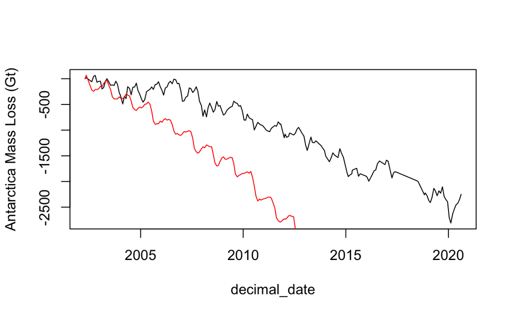

```
## integer(0)
```

```r
ant_ice_loss = read.table("data/antarctica_mass_200204_202008.txt", skip=31, sep="", header = FALSE, col.names = c("decimal_date", "mass_Gt", "sigma_Gt")) # Antarctica ice mass loss
grn_ice_loss = read.table("data/greenland_mass_200204_202008.txt", skip=31, sep="", header = FALSE, col.names = c("decimal_date", "mass_Gt", "sigma_Gt")) # Greenland ice mass loss
head(ant_ice_loss)
##   decimal_date mass_Gt sigma_Gt
## 1      2002.29    0.00   178.90
## 2      2002.35   19.38   102.47
## 3      2002.62  -58.89    83.09
## 4      2002.71   47.33    97.19
## 5      2002.79   63.53    61.82
## 6      2002.87  -68.11    58.68
head(grn_ice_loss)
##   decimal_date mass_Gt sigma_Gt
## 1      2002.29    0.00   134.28
## 2      2002.35   68.26    70.59
## 3      2002.62 -220.33    53.36
## 4      2002.71 -245.50    64.95
## 5      2002.79 -208.84    39.05
## 6      2002.87 -210.53    35.79
dim(ant_ice_loss)
## [1] 188   3
summary(ant_ice_loss)
##   decimal_date     mass_Gt            sigma_Gt
##  Min.   :2002   Min.   :-2808.73   Min.   : 26.75
##  1st Qu.:2006   1st Qu.:-1601.88   1st Qu.: 34.29
##  Median :2010   Median : -798.29   Median : 37.57
##  Mean   :2011   Mean   : -965.21   Mean   : 39.95
##  3rd Qu.:2015   3rd Qu.: -250.31   3rd Qu.: 40.17
##  Max.   :2021   Max.   :   63.53   Max.   :178.90

plot(mass_Gt ~ decimal_date, data=ant_ice_loss, ylab="Antarctica Mass Loss (Gt)", type='l') +
lines(mass_Gt ~ decimal_date, data=grn_ice_loss,type='l', col='red')
```

The plot window is sized to capture the range of the data originally called, which in this case was the Antarctica ice loss. When we added the Greendland mass loss data to the plot, it extended outside the bounds of the plot window. Let’s manually set the limits on the y-axis so we can see the whole Greenland time series.

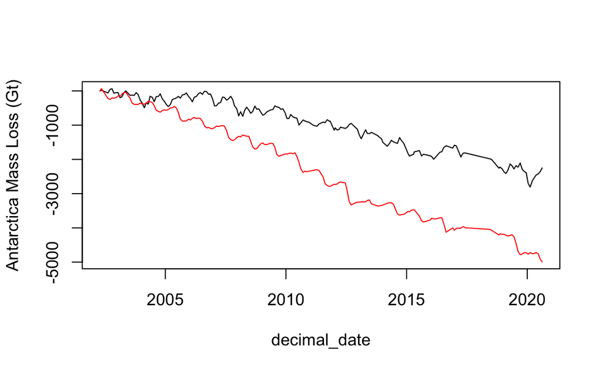

```
## integer(0)
```

```r
plot(mass_Gt ~ decimal_date, data=ant_ice_loss, ylab="Antarctica Mass Loss (Gt)", type='l', ylim=range(grn_ice_loss$mass_Gt)) +
lines(mass_Gt ~ decimal_date, data=grn_ice_loss, type='l', col='red')
```

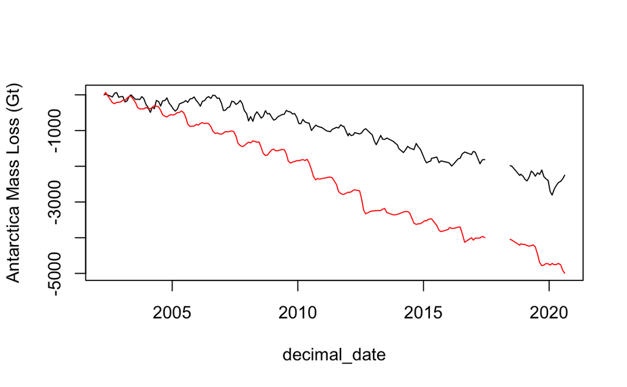

```
## integer(0)
```

```r
#Create data.frame with an NA between the GRACE missions. Column names must match so it will merge with ant and grn data
data_break = data.frame(decimal_date=2018.0, mass_Gt=NA, sigma_Gt=NA)
data_break
##   decimal_date mass_Gt sigma_Gt
## 1         2018      NA       NA

#Add NA data point to the Antarctica ice trends data frame
ant_ice_loss_with_NA = rbind(ant_ice_loss, data_break) # Merge ant_ice_loss data frame with our NA point
tail(ant_ice_loss_with_NA) # Our NA value in 2018 is now the last row of our data frame
##     decimal_date  mass_Gt sigma_Gt
## 184      2020.29 -2535.36    33.40
## 185      2020.37 -2455.98    39.45
## 186      2020.46 -2421.66    46.52
## 187      2020.54 -2352.87    54.84
## 188      2020.62 -2250.23    63.80
## 189      2018.00       NA       NA
ant_ice_loss_with_NA = ant_ice_loss_with_NA[order(ant_ice_loss_with_NA$decimal_date),] # Reorder the data frame, sorting by date

#Repeat with Greenland data.frame
grn_ice_loss_with_NA = rbind(grn_ice_loss, data_break) # Merge ant_ice_loss data frame with our NA point
grn_ice_loss_with_NA = grn_ice_loss_with_NA[order(grn_ice_loss_with_NA$decimal_date),]

plot(mass_Gt ~ decimal_date, data=ant_ice_loss_with_NA, ylab="Antarctica Mass Loss (Gt)", type='l', ylim=range(grn_ice_loss_with_NA$mass_Gt, na.rm=TRUE)) +
lines(mass_Gt ~ decimal_date, data=grn_ice_loss_with_NA, type='l', col='red')
```

NASA provided sigma, or one standard deviation, uncertainty data, which represents 68% of uncertainty. 2 X sigma represents 95% uncertainty. Plot 95% confidence intervals around the data by adding and subtracting 2*sigma from the mass loss estimates

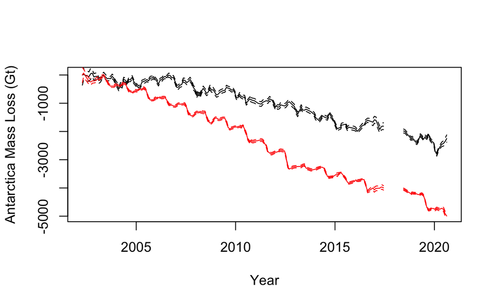

```
## integer(0)
```

```r
head(ant_ice_loss_with_NA)
##   decimal_date mass_Gt sigma_Gt
## 1      2002.29    0.00   178.90
## 2      2002.35   19.38   102.47
## 3      2002.62  -58.89    83.09
## 4      2002.71   47.33    97.19
## 5      2002.79   63.53    61.82
## 6      2002.87  -68.11    58.68
plot(mass_Gt ~ decimal_date, data=ant_ice_loss_with_NA, ylab="Antarctica Mass Loss (Gt)", xlab="Year", type='l', ylim=range(grn_ice_loss_with_NA$mass_Gt, na.rm=TRUE)) +
lines((mass_Gt+2*sigma_Gt) ~ decimal_date, data=ant_ice_loss_with_NA, type='l', lty='dashed') +
lines((mass_Gt-2*sigma_Gt) ~ decimal_date, data=ant_ice_loss_with_NA, type='l', lty='dashed') +
lines(mass_Gt ~ decimal_date, data=grn_ice_loss_with_NA, type='l', col='red') +
lines((mass_Gt+2*sigma_Gt) ~ decimal_date, data=grn_ice_loss_with_NA, type='l', lty='dashed', col="red") +
lines((mass_Gt-2*sigma_Gt) ~ decimal_date, data=grn_ice_loss_with_NA, type='l', lty='dashed', col="red")
```

To save our nice figure:

```r
pdf('figures/ice_mass_trends.pdf', width=7, height=5)
plot(mass_Gt ~ decimal_date, data=ant_ice_loss_with_NA, ylab="Antarctica Mass Loss (Gt)", xlab="Year", type='l', ylim=range(grn_ice_loss_with_NA$mass_Gt, na.rm=TRUE)) +
lines((mass_Gt+2*sigma_Gt) ~ decimal_date, data=ant_ice_loss_with_NA, type='l', lty='dashed') +
lines((mass_Gt-2*sigma_Gt) ~ decimal_date, data=ant_ice_loss_with_NA, type='l', lty='dashed') +
lines(mass_Gt ~ decimal_date, data=grn_ice_loss_with_NA, type='l', col='red') +
lines((mass_Gt+2*sigma_Gt) ~ decimal_date, data=grn_ice_loss_with_NA, type='l', lty='dashed', col="red") +
lines((mass_Gt-2*sigma_Gt) ~ decimal_date, data=grn_ice_loss_with_NA, type='l', lty='dashed', col="red")
## integer(0)
dev.off()
## quartz_off_screen
##                 2
```

Let’s make a bar plot showing the difference in ice mass loss for Antarctica and Greenland:

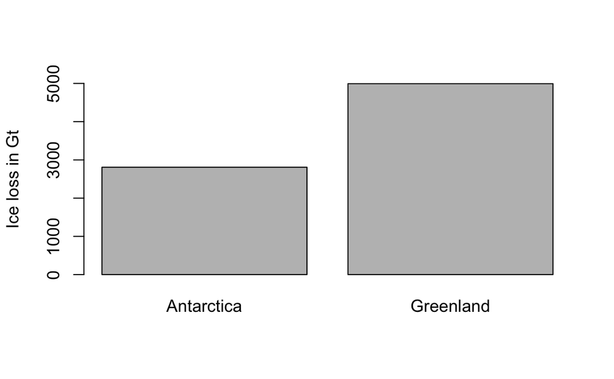

```r
barplot(height=c(min(ant_ice_loss$mass_Gt)*(-1), min(grn_ice_loss$mass_Gt)*(-1)), names.arg=c("Antarctica","Greenland"), ylim=c(0,5000), ylab="Ice loss in Gt")
```

We can calculate the average annual ice loss for each ice sheet by dividing the change in ice lost from the beginning to the end of the time series by the total time that passed. Then we can display the ice loss rates in a bar graph:

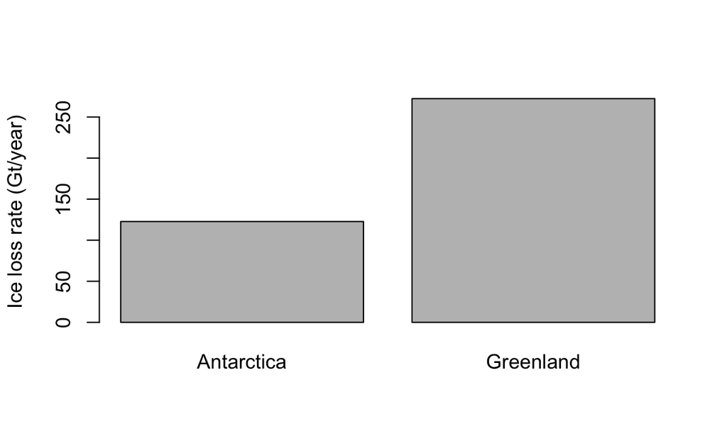

```r
# Calculate ice loss rate (Gt / year) for Antarctica:
n_rows_ant = dim(ant_ice_loss)[1]
ant_loss_rate_Gt_per_yr = -1*(ant_ice_loss$mass_Gt[n_rows_ant] - ant_ice_loss$mass_Gt[1]) / (ant_ice_loss$decimal_date[n_rows_ant] - ant_ice_loss$decimal_date[1])

# Calculate ice loss rate (Gt / year) for Greenland:
n_rows_grn = dim(grn_ice_loss)[1]
grn_loss_rate_Gt_per_yr = -1*(grn_ice_loss$mass_Gt[n_rows_grn] - grn_ice_loss$mass_Gt[1]) / (grn_ice_loss$decimal_date[n_rows_grn] - grn_ice_loss$decimal_date[1])

# Plot ice loss rates in a bar graph:
barplot(height=c(ant_loss_rate_Gt_per_yr, grn_loss_rate_Gt_per_yr), names.arg=c("Antarctica","Greenland"), ylab="Ice loss rate (Gt/year)")
```

To save our bar plot:

```r
pdf('figures/ice_loss_rate.pdf', width=5, height=5)
barplot(height=c(ant_loss_rate_Gt_per_yr, grn_loss_rate_Gt_per_yr), names.arg=c("Antarctica","Greenland"), ylab="Ice loss rate (Gt/year)")
dev.off()
## quartz_off_screen
##                 2
```